# Final_Project

Aditi Mulye

2022-04-19

## Introduction

For the purpose of completing our final project, we have decided to choose the World Bank Dataset. This dataset contains information about the suicides happening across the world from 1985-2015. Evaluating this 30 years data with respect to countries, sex, age, GDP was really insightful and led to many interesting conclusions.

However, a lot of our conclusions were limited due to lack of data. Quite a few major countries including China, India, etc were missing, thus our results could not include the suicide rates of the two most populated countries of the world.

Let’s see how we are able to gain insights from this data!

### Data Description:

This dataset consists of 12 columns and about 27000 rows ranging from 1985-2015 for each country. Columns and their information is mentioned below.

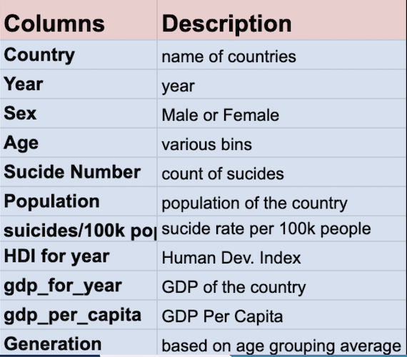

Data Info

Thus, in order to conduct a statistical analysis, our first task was to perform data cleaning.

#### Data Cleaning

- We removed 7 countries from our dataset which had less than 3 years of data thus accounting for less than 10% of data per country.
- Human Development Index(HDI) column consisted of more than 66% of the missing values, thus we dropped that column from our analysis.
- We made a new column : continent, which was derived from the countrycode package. This would help us evaluate the suicide rates across the continents with respect to various years.
- We dropped one more column named country-year because it was giving no additional information and just a combination of year and country.

## Key Insights

- Suicide rates are decreasing globally. (2.1)
- Of those countries that show clear linear trends over time, 2/3 are decreasing. (2.5.2) On average, suicide rate increases with age. (2.4)
- This remains true when controlling for continent in the Americas, Asia & Europe, but not for Africa & Oceania. (2.8)
- There is a weak positive relationship between a countries GDP (per capita) and suicide rate. (2.10)
- The highest suicide rate ever recorded in a demographic (for 1 year) is 225 (per 100k population). (2.12)
- There is an overrepresentation of men in suicide deaths at every level of analysis (globally, at a continent and country level). Globally, the male rate is ~3.5x higher. (2.3) (2.6) (2.7)

# 2 Global Analysis

## 2.1 Global Trend

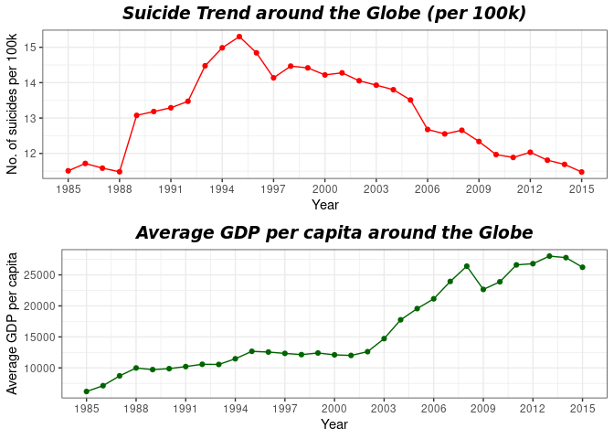

## Insights

- Peak suicide rate was 15.3 deaths per 100k in 1995
- Decreased steadily, to 11.5 per 100k in 2015 (~25% decrease)
- Rates are only now returning to their pre-90’s rates
- Limited data in the 1980’s, so it’s hard to say if rate then was truly representative of the global population

## 2.2 By Continent

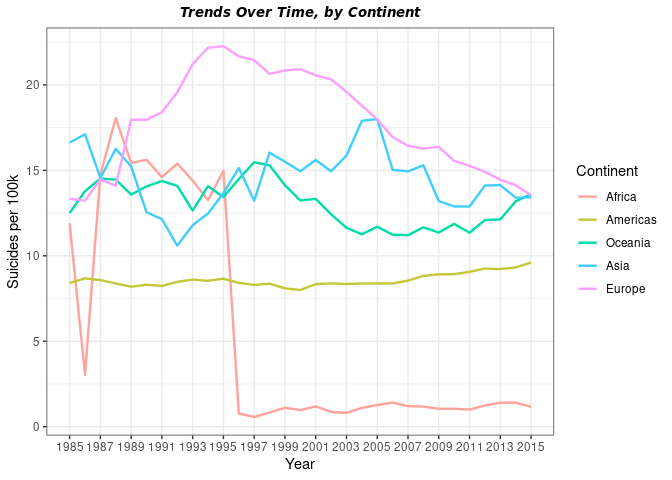

## Insights

- European rate highest overall, but has steadily decreased ~40% since 1995
- The European rate for 2015 similar to Asia & Oceania
- The trendline for Africa is due to poor data quality - just 3 countries have provided data Oceania & Americas trends are more concerning

# 2.3 By Sex

[figure not shown]

## Insights

- Globally, the rate of suicide for men has been ~3.5x higher for men
- Both male & female suicide rates peaked in 1995, declining since
- This ratio of 3.5 : 1 (male : female) has remained relatively constant since the mid 90’s However, during the 80’s this ratio was as low as 2.7 : 1 (male : female)

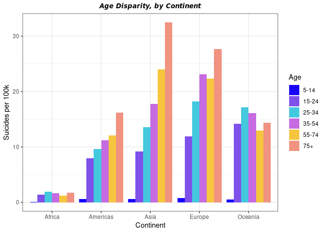

2.9 As a country gets richer, does it’s suicide rate decrease? It depends on the country - for almost every country, there is a high correlation between year and gdp per capita, i.e. as time goes on, gdp per capita linearly increases.

The mean correlation was 0.878, indicating a very strong positive linear relationship.

This basically means that looking within a country and asking “does an increase in weath (per person) have an effect suicide rate” is pretty similar to asking “does a countries suicide rate increase as time progresses”.

Instead, I ask a slightly different question below.

2.10 Do richer countries have a higher rate of suicide? Instead of looking at trends within countries, here I take every country and calculate their mean GDP (per capita) across all the years in which data is available. I then measure how this relates to the countries suicide rate across all those years.

The end result is one data point per country, intended to give a general idea of the wealth of a country and its suicide rate.

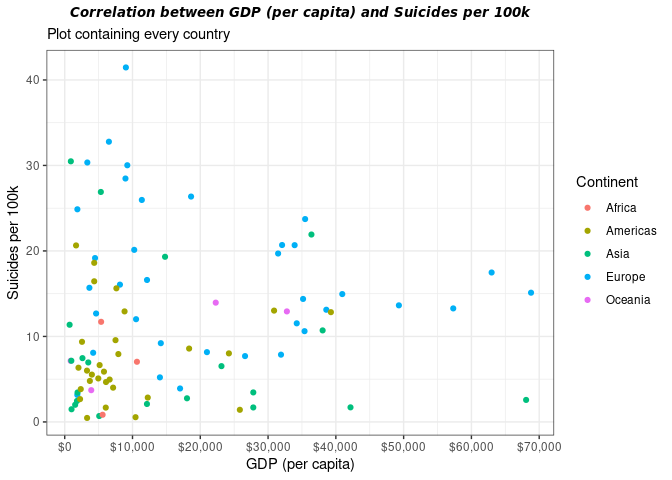

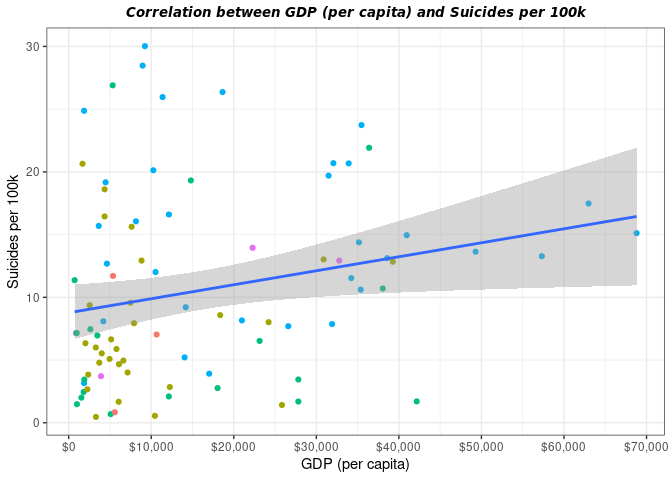

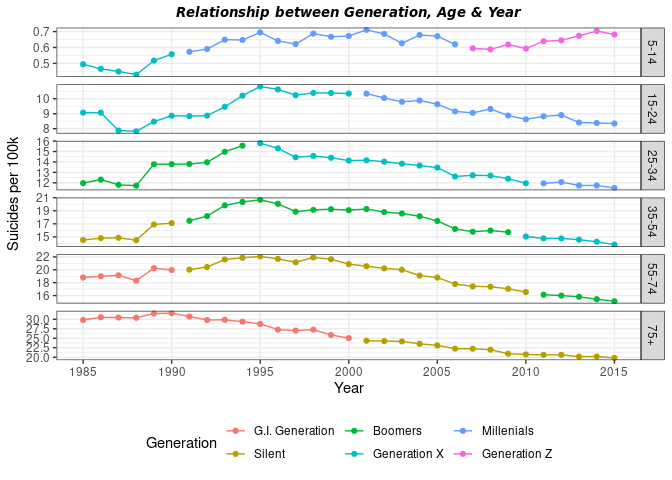

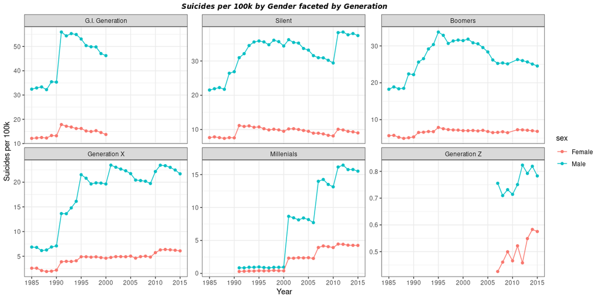

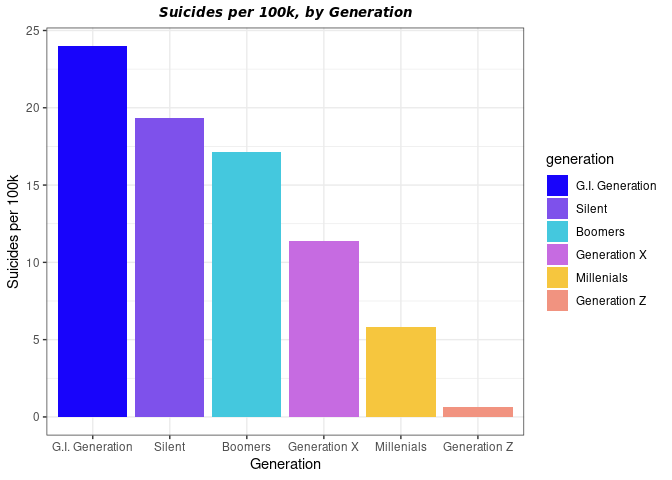

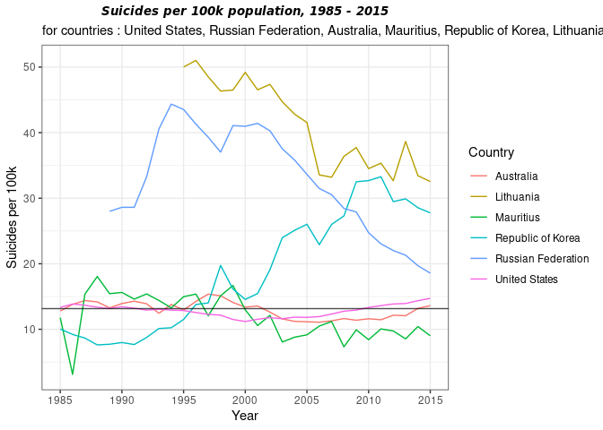

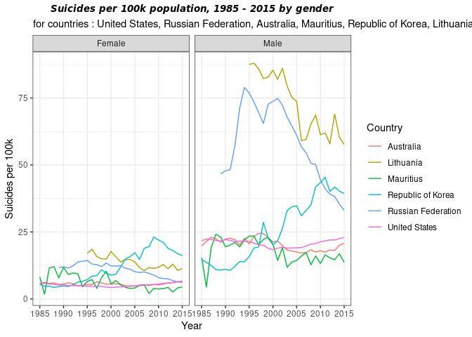

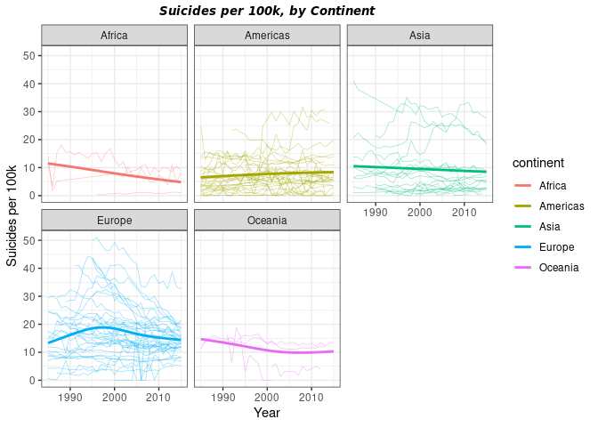